# K Means and K-Medoids exploration

2023-12-09

## Create K-medoids algo from scratch

```r
# Define a function to calculate the distance between two points
distance <- function(point1, point2) {
  return(sqrt(sum((point1 - point2)^2)))
}

# Function to assign each point to the closest medoid
assign_to_medoids <- function(points, medoids) {
  clusters <- list()
  for (i in seq_along(medoids)) {
    clusters[[i]] <- list()
  }

  for (i in seq_along(points)) {
    distances <- sapply(medoids, function(medoid) distance(points[[i]], points[[medoid]]))
    closest <- which.min(distances)
    clusters[[closest]] <- c(clusters[[closest]], i)
  }

  return(clusters)
}

# Function to update medoids
update_medoids <- function(points, clusters) {
  new_medoids <- c()
  for (cluster in clusters) {
    min_distance <- Inf
    best_medoid <- NA
    for (candidate in cluster) {
      total_distance <- sum(sapply(cluster, function(point) distance(points[[candidate]], points[[point]])))
      if (total_distance < min_distance) {
        min_distance <- total_distance
        best_medoid <- candidate
      }
    }
    new_medoids <- c(new_medoids, best_medoid)
  }

  return(new_medoids)
}

# K-medoids algorithm
k_medoids <- function(points, k, max_iter = 100) {
  # Randomly select initial medoids
  initial_medoids <- sample(length(points), k)
  medoids <- initial_medoids
  for (i in 1:max_iter) {
    clusters <- assign_to_medoids(points, medoids)
    new_medoids <- update_medoids(points, clusters)
    if (all(new_medoids == medoids)) {
      break
    }
    medoids <- new_medoids
  }
  list(medoids = medoids, clusters = clusters)
}

# Example usage
# points <- list(c(1,2), c(3,4), ...)
# result <- k_medoids(points, k = 3)
# result$medoids # The final medoids
# result$clusters # The final cluster assignments
```

### Convert a nxp data matrix to a list

```r
n <- nrow(data_matrix)
points <- vector("list", n)

for (i in 1:n) {
  points[[i]] <- data_matrix[i, ]
}
```

### Generate random 2D data to test k-medoids algo

The DGP indicates true number of clusters is 2

```r
# Generate data
library(MASS)
Sigma <- matrix(c(1.5, 0.4, 0.4, 1.5), nrow = 2)
mu1 <- c(0, -2)
mu2 <- c(6, 2)
n <- 200
d1 <- mvrnorm(n = n/2, mu = mu1, Sigma = Sigma)
d2 <- mvrnorm(n = n/2, mu = mu2, Sigma = Sigma)
x <- rbind(d1, d2)

# Initialize cluster center
set.seed(1998)
idx <- sample(nrow(x), 2)
m1 <- x[idx[1],]
m2 <- x[idx[2],]

# Convert to list
n <- nrow(x)
points <- vector("list", n)

for (i in 1:n) {
  points[[i]] <- x[i, ]
}
```

We plot the intial centroids

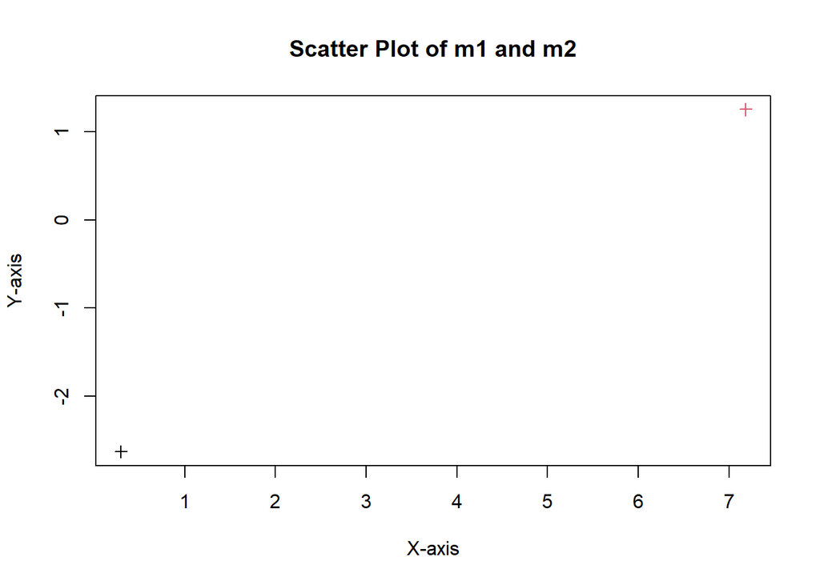

```r
# Plot initial centroids

# Assuming m1 and m2 are vectors with 2 elements each
# Example: m1 <- c(x1, y1), m2 <- c(x2, y2)

# Set up the plot limits
xlim <- range(c(m1[1], m2[1]))
ylim <- range(c(m1[2], m2[2]))

# Create an empty plot with specified limits
plot(0, type = "n", xlim = xlim, ylim = ylim, xlab = "X-axis", ylab = "Y-axis", main = "Scatter Plot of m1 and m2")

# Add points m1 and m2 to the plot
points(x = m1[1], y = m1[2], pch = 3, cex = 1, col = 1)
points(x = m2[1], y = m2[2], pch = 3, cex = 1, col = 2)
```

Then we plot the initial clusters

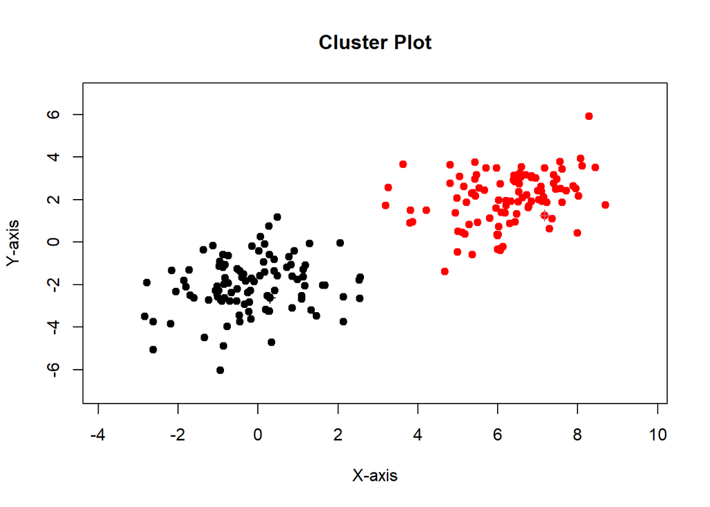

```r
# Plot initial clusters
# Assuming 'points' is your list of data points
# and 'clusters' is the output from 'assign_to_medoids' function
cluster_v0 <- assign_to_medoids(points, idx)

plot(NULL, xlim = range(sapply(points, `[`, 1)) + c(-1, 1), ylim = range(sapply(points, `[`, 2)) + c(-1, 1), xlab = "X-axis", ylab = "Y-axis", main = "Cluster Plot")

# Plot each cluster with a different color
colors <- c("black", "red")

for (i in seq_along(cluster_v0)) {
  cluster_points_v0 <- matrix(unlist(lapply(cluster_v0[[i]], function(idx) points[[idx]])), ncol = 2, byrow = TRUE)
  points(cluster_points_v0[, 1], cluster_points_v0[, 2], col = colors[i], pch = 19)
}

points(x = m1[1], y = m1[2], pch = 3, cex = 1, col = 1)
points(x = m2[1], y = m2[2], pch = 3, cex = 1, col = 2)
```

#### Explanation of cluster_points_v0

**Context**

In the context of the k-medoids algorithm:

*points*: A list where each element is a data point (a vector of coordinates). *clusters*: A list of clusters, where each cluster contains the indices of the data points in points that belong to that cluster.

**Goal**

The goal of the line of code in question is to transform the indices of the data points in a cluster (found in clusters[[i]]) into the actual data points themselves (from points).

**Explanation**

1. `clusters[[i]]:` This is a vector containing the indices of the data points that belong to the i-th cluster. For example, if clusters[[i]] is c(2, 5), it means the second and fifth points in points belong to the i-th cluster.
2. `lapply(...):` lapply is a function that applies another function to each element of a list or a vector and returns a list. In this case, it’s being applied to the vector clusters[[i]].
3. `The Anonymous Function function(idx) points[[idx]]:` This function is defined to take an index (idx) and return the corresponding data point from points. For each element (index) in clusters[[i]], lapply applies this function. For example, if idx is 2, points[[idx]] returns the second element of points, which is the actual data point.

**Result**

The result of lapply(clusters[[i]], function(idx) points[[idx]]) is a list of data points that belong to the i-th cluster. Each element of this list is a vector representing a data point. This operation effectively translates the indices in clusters[[i]] into the actual data points from points.

**Why Is This Done?**

This process is essential because the clustering information is stored as indices in clusters. To perform operations like plotting these points or calculating distances, you need the actual data points, not just their indices.

By retrieving the actual points, you can then perform further operations like plotting these points on a scatter plot or computing distances for the k-medoids algorithm.

In summary, this line of code is a critical step in transforming the cluster assignments (which are indices of points) back into the actual data points, enabling further manipulation and analysis.

Next we compute the objective function and print it. Recall obj. value is the l2 distance

```r
# Compute and Print value of obj. function
# Assuming 'distance' is the function to calculate the distance between points
compute_distance <- function(points, clusters, medoids) {
  total_distance <- 0
  for (i in seq_along(clusters)) {
    medoid <- points[[medoids[i]]]
    for (point_idx in clusters[[i]]) {
      point <- points[[point_idx]]
      total_distance <- total_distance + distance(point, medoid)
    }
  }
  return(total_distance)
}

# Compute the objective function value
obj <- compute_distance(points, cluster_v0, idx)
print(obj)
```

```
## [1] 354.3481
```

### 1st Iteration

Next, we update the centroids

```r
idx2 <- update_medoids(points, cluster_v0)
cat(sprintf("updated medoid: %s \noriginal medoid: %s\n",
            paste(idx2, collapse=" "),
            paste(idx, collapse=" ")))
```

```
## updated medoid: 23 154
## original medoid: 82 137
```

And the new obj value is

```r
obj2 <- compute_distance(points, cluster_v0, idx2)
print(obj2)
```

```
## [1] 301.4292
```

We see a significant decrease in the objective value, which is indeed the desired outcome. Next, we update the cluster assignments and plot the new cluster along with the new centroids. We repeat this step for a few iterations, each time plotting the scatterplot for visual comparison.

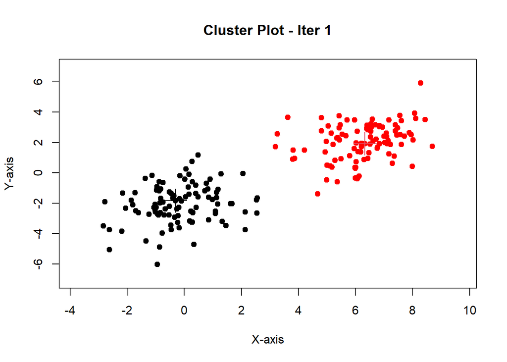

```r
# New cluster assignment
cluster_v1 <- assign_to_medoids(points, idx2)

# Plot new clusters along with centroids
plot(NULL, xlim = range(sapply(points, `[`, 1)) + c(-1, 1), ylim = range(sapply(points, `[`, 2)) + c(-1, 1), xlab = "X-axis", ylab = "Y-axis", main = "Cluster Plot - Iter 1")

# Plot each cluster with a different color
colors <- c("black", "red")

for (i in seq_along(cluster_v1)) {
  cluster_points_v1 <- matrix(unlist(lapply(cluster_v1[[i]], function(idx2) points[[idx2]])), ncol = 2, byrow = TRUE)
  points(cluster_points_v1[, 1], cluster_points_v1[, 2], col = colors[i], pch = 19)
}

# New centroids
m1 <- x[idx2[1],]
m2 <- x[idx2[2],]
points(x = m1[1], y = m1[2], pch = 3, cex = 3, col = 1)
points(x = m2[1], y = m2[2], pch = 3, cex = 3, col = 2)
```

#### 2nd iteration

```r
idx3 <- update_medoids(points, cluster_v1)
cat(sprintf("iter 2 medoid: %s \niter 1 medoid: %s \noriginal medoid: %s\n",
            paste(idx3, collapse = " "),
            paste(idx2, collapse=" "),
            paste(idx, collapse=" ")))
```

```
## iter 2 medoid: 23 154
## iter 1 medoid: 23 154
## original medoid: 82 137
```

Notice that the newly updated medoid is unchanged. This means we have reached convergence point and there is no better medoids, based on l2 distance.

## Robustness of K-medoids Clustering

```r
# Given dataframe

dt <- data.frame(
  X1 = c(0.2, 0.3, 0.4, 0.5, 1.0, 1.2, -0.2, -0.3, -0.4),
  X2 = c(0, 0, 0, 0, 0.2, 0.1, 0, 0, 0),
  true_label = c(1, 1, 1, 1, 1, 1, 2, 2, 2)
)

# Display the dataframe
print(dt)
```

```
##     X1  X2 true_label
## 1  0.2 0.0          1
## 2  0.3 0.0          1
## 3  0.4 0.0          1
## 4  0.5 0.0          1
## 5  1.0 0.2          1
## 6  1.2 0.1          1
## 7 -0.2 0.0          2
## 8 -0.3 0.0          2
## 9 -0.4 0.0          2
```

```r
# Convert dataframe to list for K-medoids algorithm
dt_mat <- as.matrix(cbind(dt$X1, dt$X2))

n <- nrow(dt_mat)
dt_list <- vector("list", n)

for (i in 1:n) {
  dt_list[[i]] <- dt_mat[i,]
}

dt_list
```

```
## [[1]]
## [1] 0.2 0.0
##
## [[2]]
## [1] 0.3 0.0
##
## [[3]]
## [1] 0.4 0.0
##
## [[4]]
## [1] 0.5 0.0
##
## [[5]]
## [1] 1.0 0.2
##
## [[6]]
## [1] 1.2 0.1
##
## [[7]]
## [1] -0.2  0.0
##
## [[8]]
## [1] -0.3  0.0
##
## [[9]]
## [1] -0.4  0.0
```

### K-medoids clustering

```r
# Set seed
set.seed(1998)

result <- k_medoids(dt_list, 2)
print(result)
```

```
## $medoids
## [1] 3 8
##
## $clusters
## $clusters[[1]]
## $clusters[[1]][[1]]
## [1] 1
##
## $clusters[[1]][[2]]
## [1] 2
##
## $clusters[[1]][[3]]
## [1] 3
##
## $clusters[[1]][[4]]
## [1] 4
##
## $clusters[[1]][[5]]
## [1] 5
##
## $clusters[[1]][[6]]
## [1] 6
##
##
## $clusters[[2]]
## $clusters[[2]][[1]]
## [1] 7
##
## $clusters[[2]][[2]]
## [1] 8
##
## $clusters[[2]][[3]]
## [1] 9
```

We also visualize the result

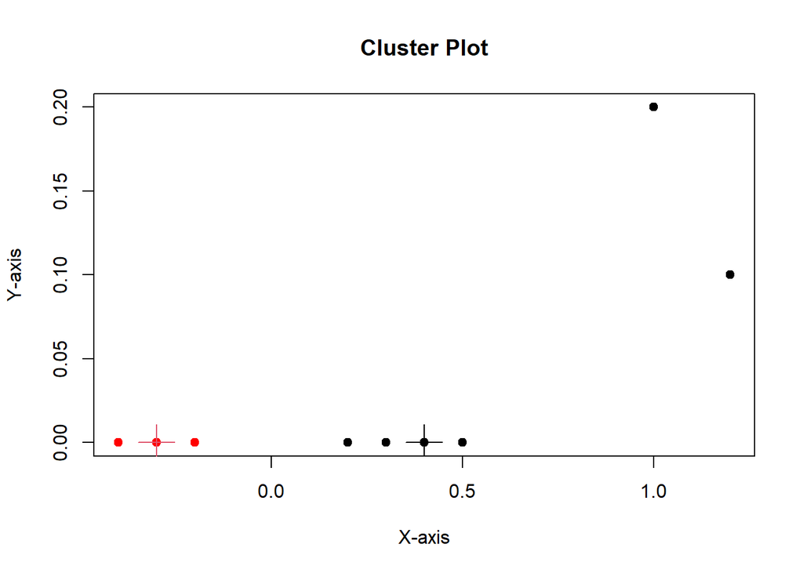

```r
plot(NULL, xlim = range(sapply(dt_list, `[`, 1)), ylim = range(sapply(dt_list, `[`, 2)), xlab = "X-axis", ylab = "Y-axis", main = "Cluster Plot")

# Plot each cluster with a different color
colors <- c("black", "red")

for (i in seq_along(result$clusters)) {
  cluster_points <- matrix(unlist(lapply(result$clusters[[i]], function(idx) dt_list[[idx]])), ncol = 2, byrow = TRUE)
  points(cluster_points[, 1], cluster_points[, 2], col = colors[i], pch = 19)
}

# Add centroids to plot
m1 <- dt_mat[result$medoids[1],]
m2 <- dt_mat[result$medoids[2],]
points(x = m1[1], y = m1[2], pch = 3, cex = 3, col = 1)
points(x = m2[1], y = m2[2], pch = 3, cex = 3, col = 2)
```

### K-means clustering

```r
# Assuming the dataframe is named 'data'
# First, select only the feature columns for clustering
features <- dt[, c('X1', 'X2')]

# Apply k-means clustering with k = 2 clusters
set.seed(1998)

kmeans_result <- kmeans(features, centers = 2)

# View the results
print(kmeans_result)
```

```
## K-means clustering with 2 clusters of sizes 2, 7
##
## Cluster means:
##           X1   X2
## 1 1.10000000 0.15
## 2 0.07142857 0.00
##
## Clustering vector:
## [1] 2 2 2 2 1 1 2 2 2
##
## Within cluster sum of squares by cluster:
## [1] 0.0250000 0.7942857
##  (between_SS / total_SS =  67.2 %)
##
## Available components:
##
## [1] "cluster"      "centers"      "totss"        "withinss"     "tot.withinss"
## [6] "betweenss"    "size"         "iter"         "ifault"
```

Next, before we plot the result, we convert the kmeans_result cluster label to match the true label.

```r
# Check which cluster most often corresponds to which true label
table(dt$true_label, kmeans_result$cluster)
```

```
##
##     1 2
##   1 2 4
##   2 0 3
```

```r
# If cluster 1 corresponds mostly to true label 2 and vice versa, you can recode the clusters
dt$recode_cluster <- ifelse(kmeans_result$cluster == 1, 2, 1)
```

Now, we plot the result.

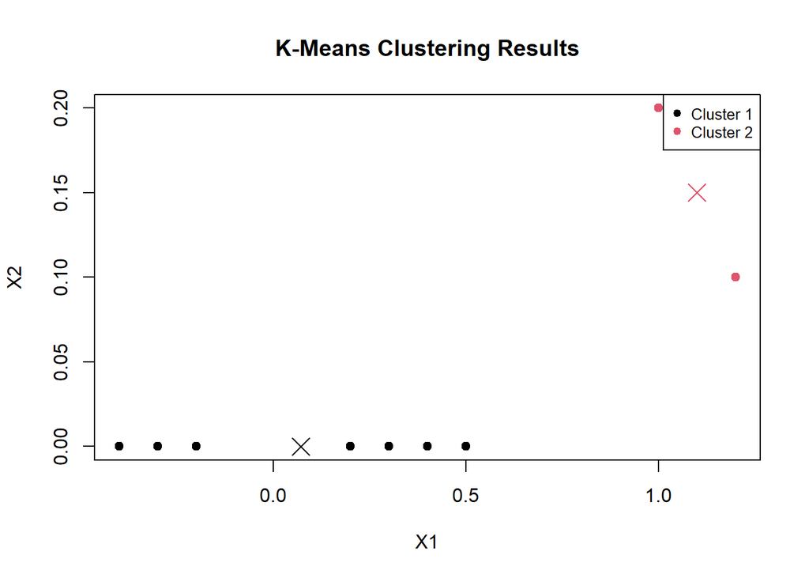

```r
# Plot the data points with different colors for different clusters
plot(dt$X1, dt$X2, xlim = range(sapply(dt_list, `[`, 1)), ylim = range(sapply(dt_list, `[`, 2)), col = dt$recode_cluster, pch = 19,
     xlab = "X1", ylab = "X2", main = "K-Means Clustering Results")

# Optionally, add the cluster centers to the plot
centers <- kmeans_result$centers
points(centers[,1], centers[,2], col = 2:1, pch = 4, cex = 2)

# Add a legend to the plot
legend("topright", legend = c("Cluster 1", "Cluster 2"),
       col = 1:2, pch = 19, cex = 0.8)
```

### Discussion

We see that observation 5 and 6 are outliers for label 1, so using the k-means clustering results in the algorithm assigning incorrect labels.

In other words, k-means is not robust to outliers.

Meanwhile, using the k-medoids method results in algorithm assigning the correct labels, implying that this method is robust to outliers, as expected.